````bash
```bash
# https://github.com/vivischuch/MSM_Rclass.git
````

[output not shown]

[output not shown]

**What is a GSE:**

A GSE refers to a “Gene Expression Omnibus Series.” It’s part of the Gene Expression Omnibus (GEO), a public database hosted by the National Center for Biotechnology Information (NCBI). GEO is a repository that stores high-throughput gene expression data, as well as other types of molecular abundance data, submitted by the scientific community.

https://www.ncbi.nlm.nih.gov/geo/

A GSE record in GEO represents a series, which is essentially a collection of related samples. Each GSE contains descriptions of the experiment’s overall design and purpose, as well as links to more detailed data about individual samples (referred to as GSM records) and the platform used for measurement (GPL records).

To begin an analysis in R, one would typically start by defining the specific GSE study identifier. For example, let see the data from this paper: https://www.ncbi.nlm.nih.gov/pmc/articles/PMC6092567/

```r
# Define study
gse <- "GSE66273"  # Study identifier
```

Once the study is defined, the analysis focuses on an ExpressionSet object, a key structure in microarray data analysis from GEO datasets. This object comprises several crucial components:

- **Expression Data**: The core of the ExpressionSet, containing gene expression measurements in a matrix format.
- **Phenotypic Data (pData)**: Information about the samples or experimental conditions, organized in a data frame.
- **Feature Data (fData)**: Detailed information about the microarray’s features (genes or probes).

The next step involves downloading and reading the GEO dataset into an ExpressionSet object. This is done using the GEOquery package, as shown below:

```r
# Download and read GEO dataset into an ExpressionSet object
eset <- getGEO(gse, GSEMatrix = TRUE)
# View the names of objects in the ExpressionSet list
names(eset)
```

```
[1] "GSE66273_series_matrix.txt.gz"
```

```r
# Select the first ExpressionSet from the list
eset_1 <- eset[[1]]
```

**Getting expression values from ExpressionSet**

After obtaining the ExpressionSet, the next step is to convert the expression data into a more accessible format like a data frame. This allows for easier viewing and manipulation of the data:

```r
# Convert expression data from ExpressionSet to a data frame
expr <- as.data.frame(Biobase::exprs(eset_1))
# Display the first few rows of the expression data
head(expr)
```

|  | GSM1618441 | GSM1618442 | GSM1618443 | GSM1618444 | GSM1618445 | GSM1618446 | GSM1618447 | GSM1618448 | GSM1618449 | GSM1618450 | GSM1618451 | GSM1618452 | GSM1618453 | GSM1618454 | GSM1618455 | GSM1618456 | GSM1618457 |
| --- | --- | --- | --- | --- | --- | --- | --- | --- | --- | --- | --- | --- | --- | --- | --- | --- | --- |
| 1 | 14.92 | 10.97 | 14.97 | 11.59 | 15.17 | 14.65 | 12.99 | 13.35 | 11.02 | 14.36 | 10.96 | 10.19 | 9.32 | 12.38 | 14.11 | 15.30 | 13.19 |
| 2 | 4.49 | 4.27 | 4.62 | 4.09 | 4.85 | 4.71 | 4.01 | 4.05 | 4.25 | 4.11 | 4.02 | 4.30 | 4.72 | 4.32 | 3.88 | 4.19 | 4.39 |
| 3 | 4.55 | 3.94 | 4.51 | 4.27 | 4.76 | 4.74 | 3.94 | 3.97 | 4.09 | 4.20 | 4.24 | 4.41 | 4.66 | 4.36 | 4.30 | 3.92 | 4.45 |
| 4 | 4.68 | 4.17 | 4.51 | 4.27 | 4.72 | 4.92 | 6.35 | 4.19 | 4.30 | 4.02 | 4.09 | 4.18 | 4.72 | 4.47 | 4.08 | 3.71 | 4.39 |
| 5 | 4.62 | 3.94 | 4.44 | 4.12 | 4.66 | 4.77 | 4.09 | 3.71 | 4.39 | 4.02 | 4.02 | 4.11 | 4.45 | 4.44 | 4.12 | 2.97 | 4.10 |
| 6 | 4.68 | 4.17 | 4.58 | 4.30 | 4.66 | 4.97 | 3.67 | 3.90 | 4.50 | 4.16 | 4.17 | 4.03 | 4.63 | 4.51 | 3.88 | 3.81 | 4.32 |

**Aligning Phenotype Data with ExpressionSet Columns**

This step involves aligning the phenotype data with the expression data columns. This ensures that each sample’s expression data corresponds correctly to its phenotypic information:

```r
# Extract phenotype data from the ExpressionSet
phenoData_GEO_1 <- pData(eset_1)
# Align the columns of the expression data with the phenotype data
index <- match(colnames(expr), phenoData_GEO_1$geo_accession)
# Reorder phenotype data to match the order in the expression data
phenoData_GEO_1 <- phenoData_GEO_1[c(index),]
# Check if the geo_accession in phenoData matches the column names in expr
table(phenoData_GEO_1$geo_accession == colnames(expr))
```

```
TRUE
  17
```

**Processing and Classifying Phenotype Data in phenoData**

This section of the code focuses on processing and classifying the phenotype data within the phenoData dataframe. The objective is to categorize samples into groups like ‘Patient’ and ‘Control’ for comparative analysis in transcriptomic studies.

```r
# Create a new column 'group' in phenoData and initialize with NA
phenoData_GEO_1$group <- NA

# Duplicate the 'title' column for further modification
phenoData_GEO_1$title2 <- phenoData_GEO_1$title

# Display the updated data frame
print(phenoData_GEO_1$title2)
```

```
 [1] "Preterm control placenta (3042)"                       "Preterm control placenta (3053)"
 [3] "Preterm control placenta (3055)"                       "Preterm control placenta (kk04)"
 [5] "Preterm control placenta (kk06)"                       "Preterm preeclampsia placenta (3008)"
 [7] "Preterm preeclampsia placenta (3019)"                  "Preterm preeclampsia placenta (3020)"
 [9] "Preterm preeclampsia placenta (3025)"                  "Preterm preeclampsia placenta (3030)"
[11] "Preterm preeclampsia placenta (3047)"                  "Preterm preeclampsia + HELLP syndrome placenta (3001)"
[13] "Preterm preeclampsia + HELLP syndrome placenta (3010)" "Preterm preeclampsia + HELLP syndrome placenta (3013)"
[15] "Preterm preeclampsia + HELLP syndrome placenta (3014)" "Preterm preeclampsia + HELLP syndrome placenta (3018)"
[17] "Preterm preeclampsia + HELLP syndrome placenta (3024)"
```

Regular expressions **(regex)** are used here to parse and modify the ‘title’ column, simplifying it for easier classification of samples. This step is crucial for accurate grouping in later analyses.

```r
# We will use a regular expression (regex) in R to extract the first three words from each string in the 'title2' column.
phenoData_GEO_1$title2 <- sub("^((\\S+\\s+){2}\\S+).*", "\\1", phenoData_GEO_1$title2)

# Replace spaces in the extracted titles with underscores
phenoData_GEO_1$title2 <- gsub(" ", "_", phenoData_GEO_1$title2)

# Rename 'group' column to 'Class' and 'geo_accession' to 'Sample' for consistency
colnames(phenoData_GEO_1)[colnames(phenoData_GEO_1) == "group"] <- "Class"
colnames(phenoData_GEO_1)[colnames(phenoData_GEO_1) == "geo_accession"] <- "Sample"

print(phenoData_GEO_1$title2)
```

```
 [1] "Preterm_control_placenta"      "Preterm_control_placenta"      "Preterm_control_placenta"      "Preterm_control_placenta"
 [5] "Preterm_control_placenta"      "Preterm_preeclampsia_placenta" "Preterm_preeclampsia_placenta" "Preterm_preeclampsia_placenta"
 [9] "Preterm_preeclampsia_placenta" "Preterm_preeclampsia_placenta" "Preterm_preeclampsia_placenta" "Preterm_preeclampsia_+"
[13] "Preterm_preeclampsia_+"        "Preterm_preeclampsia_+"        "Preterm_preeclampsia_+"        "Preterm_preeclampsia_+"
[17] "Preterm_preeclampsia_+"
```

```r
# Classify samples based on title and filter out samples with missing class
phenoData_GEO_1 <- phenoData_GEO_1 %>%
  dplyr::mutate(Class = case_when(title2 %in% c("Preterm_preeclampsia_placenta")~"Patient",
                           title2 %in% c("Preterm_control_placenta")~"Control")) %>%
  dplyr::filter(!is.na(Class))

# Select specific columns and rearrange them
phenoData_GEO_1 <- phenoData_GEO_1 %>%
  dplyr::select(Sample, Class, everything())
```

**Aligning and preparing expression data with sample annotations**

Now, the focus shifts to aligning the expression data with the phenotype data. This alignment is vital for ensuring that each sample’s expression data is correctly associated with its corresponding phenotypic information.

```r
# Align columns of expression data with the sample annotation
index <- match(phenoData_GEO_1$Sample, colnames(expr))
expr <- expr[,c(index)]

# Verify alignment of Sample names in phenoData with column names in expr
table(phenoData_GEO_1$Sample == colnames(expr))
```

```
TRUE
  11
```

```r
# Convert 'Class' column in phenoData to a factor
phenoData_GEO_1$Class <- factor(phenoData_GEO_1$Class)
# # Define group names (not used directly in the code)
groups <- make.names(c("Control","Patient"))
```

**Convert Expression Data to a Matrix**

Converting the expression data to a matrix format facilitates more efficient processing in subsequent analytical steps.

```r
ex <- as.matrix(expr)
```

**Box-plot**

Boxplots are essential tools in transcriptomic analysis. They provide a visual summary of gene expression data, highlighting median, distribution, and variability across different samples or conditions. This step is instrumental in quality control and preliminary data assessment.

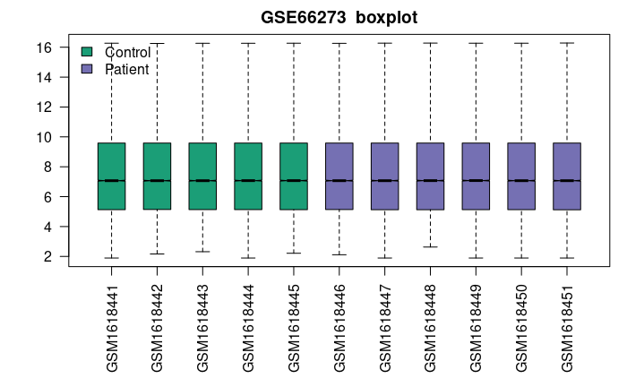

```r
# saving a plot as a PNG image
# png(filename = paste0("boxplot_", gse, ".png"), width = 800, height = 600)

# Order samples by their class for plotting
ord <- order(phenoData_GEO_1$Class)
# Set color palette for the plot
palette(c("#1B9E77", "#7570B3", "#E7298A", "#E6AB02", "#D95F02",
          "#66A61E", "#A6761D", "#B32424", "#B324B3", "#666666"))
# Set plot margins
par(mar=c(7,4,2,1))
# Define title for the boxplot
title <- paste0(gse, " ", " boxplot")
# Create the boxplot with specified parameters
boxplot(ex[,ord], boxwex=0.6, notch=T, main=title, outline=FALSE, las=2, col=phenoData_GEO_1$Class[ord])
legend("topleft", groups, fill=palette(), bty="n")
```

```r
# turn off the current graphics device:
# dev.off()
```

**UMAP plot**

UMAP is a technique used for dimensionality reduction and visualization in transcriptomic data analysis. It helps in uncovering patterns and relationships within complex gene expression data, aiding in the identification of clusters and batch effects.

```r
# Perform UMAP dimensionality reduction
ump <- umap(t(ex), n_neighbors = 10, random_state = 123)

# saving a plot as a PNG image
# png(filename = paste0("UMAP_", gse, ".png"), width = 800, height = 600)

# Set plot parameters
par(mar=c(3,3,2,6), xpd=TRUE)
# Plot UMAP results
plot(ump$layout, main=paste0(gse, " ", " UMAP plot, nbrs=10"), xlab="", ylab="", col=phenoData_GEO_1$Class, pch=20, cex=4)
# Add legend to the plot
legend("bottomright", legend=levels(phenoData_GEO_1$Class), pch=20, col=1:nlevels(phenoData_GEO_1$Class), title="Group", pt.cex=2)
```

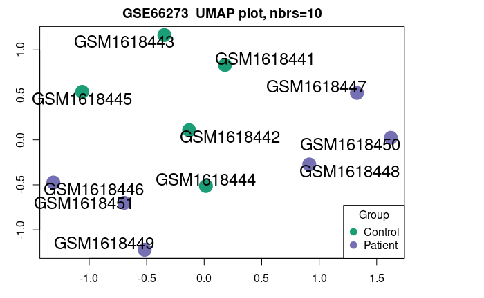

```r
# Place point labels using maptools
pointLabel(ump$layout, labels = rownames(ump$layout), method="SANN", cex=1.5)
```

```r
# turn off the current graphics device:
# dev.off()
```

**Expression Value Distribution Analysis**

Density plots offer a detailed view of gene expression distribution, crucial for understanding overall expression patterns and guiding further analysis.

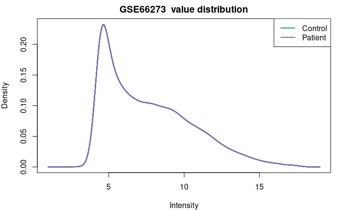

```r
# saving a plot as a PNG image
# png(filename = paste0("density_", gse, ".png"), width = 800, height = 600)

# Set plot margins
par(mar=c(4,4,2,1))
# Define title for the density plot
title <- paste0(gse, " ", " value distribution")
# Create density plot for expression
plotDensities(ex, group=phenoData_GEO_1$Class, main=title, legend ="topright")
```

```r
# turn off the current graphics device:
# dev.off()
```

**Expression Table Check**

This step involves checking the ‘expr’ data frame for missing values and understanding its structure, ensuring data integrity before proceeding.

```r
# Check for missing values in the 'expr' data frame
table(is.na(expr))
```

```
 FALSE
495165
```

```r
# Display the structure of the 'expr' data frame, showing its dimensions, column names, and data types.
str(expr)
```

```
'data.frame':   45015 obs. of  11 variables:
 $ GSM1618441: num  14.92 4.49 4.55 4.68 4.62 ...
 $ GSM1618442: num  10.97 4.27 3.94 4.17 3.94 ...
 $ GSM1618443: num  14.97 4.62 4.51 4.51 4.44 ...
 $ GSM1618444: num  11.59 4.09 4.27 4.27 4.12 ...
 $ GSM1618445: num  15.17 4.85 4.76 4.72 4.66 ...
 $ GSM1618446: num  14.65 4.71 4.74 4.92 4.77 ...
 $ GSM1618447: num  12.99 4.01 3.94 6.35 4.09 ...
 $ GSM1618448: num  13.35 4.05 3.97 4.19 3.71 ...
 $ GSM1618449: num  11.02 4.25 4.09 4.3 4.39 ...
 $ GSM1618450: num  14.36 4.11 4.2 4.02 4.02 ...
 $ GSM1618451: num  10.96 4.02 4.24 4.09 4.02 ...
```

**Extract Feature Data**

Extracting feature data is necessary to associate gene expression levels with specific genes or probes, providing a deeper understanding of the data.

```r
feature_data <- Biobase::fData(eset_1)
# Display the structure of 'feature_data' to understand its format and contents.
str(feature_data)
```

```
'data.frame':   45015 obs. of  22 variables:
 $ ID                  : int  1 2 3 4 5 6 7 8 9 10 ...
 $ COL                 : int  266 266 266 266 266 266 266 266 266 266 ...
 $ ROW                 : int  170 168 166 164 162 160 158 156 154 152 ...
 $ NAME                : chr  "GE_BrightCorner" "DarkCorner" "DarkCorner" "DarkCorner" ...
 $ SPOT_ID             : chr  "GE_BrightCorner" "DarkCorner" "DarkCorner" "DarkCorner" ...
 $ CONTROL_TYPE        : chr  "pos" "pos" "pos" "pos" ...
 $ REFSEQ              : chr  "" "" "" "" ...
 $ GB_ACC              : chr  "" "" "" "" ...
 $ GENE                : int  NA NA NA NA NA NA NA NA NA NA ...
 $ GENE_SYMBOL         : chr  "" "" "" "" ...
 $ GENE_NAME           : chr  "" "" "" "" ...
 $ UNIGENE_ID          : chr  "" "" "" "" ...
 $ ENSEMBL_ID          : chr  "" "" "" "" ...
 $ TIGR_ID             : chr  "" "" "" "" ...
 $ ACCESSION_STRING    : chr  "" "" "" "" ...
 $ CHROMOSOMAL_LOCATION: chr  "" "" "" "" ...
 $ CYTOBAND            : chr  "" "" "" "" ...
 $ DESCRIPTION         : chr  "" "" "" "" ...
 $ GO_ID               : chr  "" "" "" "" ...
 $ SEQUENCE            : chr  "" "" "" "" ...
 $ SPOT_ID.1           : logi  NA NA NA NA NA NA ...
 $ ORDER               : int  1 2 3 4 5 6 7 8 9 10 ...
```

**Refining Expression Data**

Refining the expression data involves adding gene symbols and cleaning the data by removing entries with missing or blank gene symbols.

```r
# Add a new column 'GeneSymbol' to 'expr' by copying the 'GENE_SYMBOL' column from 'feature_data'.
expr$GeneSymbol <- feature_data$GENE_SYMBOL
# Count the number of rows (genes) in 'expr' before any data cleaning.
nrow(expr)
```

```
[1] 45015
```

```r
# Reorder columns in 'expr', making 'GeneSymbol' the first column, and assign the result to 'expr_gene'.
expr_gene <- expr %>%
  dplyr::select(GeneSymbol, everything())
# Remove rows from 'expr_gene' where 'GeneSymbol' is blank or NA, effectively cleaning the data.
expr_gene <- expr_gene %>%
  filter(GeneSymbol != "") %>%
  filter(!is.na(GeneSymbol))
# Count the number of rows in 'expr_gene' after removing probes with missing or blank 'GeneSymbol'.
nrow(expr_gene)
```

```
[1] 32696
```

**Summarizing Expression Data by Mean**

```r
# Calculate the mean expression for each gene across all samples and add it as a new column 'mean_exprs'.
expr_gene_probe_mean <- expr_gene %>%
  mutate(mean_exprs = apply(expr_gene[,2:ncol(expr_gene)], 1, mean))
# Group the data by 'GeneSymbol', then select the top row per group based on 'mean_exprs' value.
expr_gene_summarized_by_mean <- expr_gene_probe_mean %>%
  group_by(GeneSymbol) %>%
  top_n(1, mean_exprs)
# Count the number of rows in 'expr_gene_summarized_by_mean' after summarization.
nrow(expr_gene_summarized_by_mean)
```

```
[1] 19749
```

```r
# Remove the 'mean_exprs' column from the data, as it's no longer needed after summarization.
expr_gene_summarized_by_mean <- expr_gene_summarized_by_mean %>%
  dplyr::select(-mean_exprs)
```

This final step involves converting the ‘GeneSymbol’ column into row names.

```r
# Convert 'GeneSymbol' into row names of 'expr_gene_summarized_by_mean'.
expr2 <- data.frame(column_to_rownames(expr_gene_summarized_by_mean, var = "GeneSymbol"))
# Check the names of the columns in 'expr2'.
colnames(expr2)
```

```
 [1] "GSM1618441" "GSM1618442" "GSM1618443" "GSM1618444" "GSM1618445" "GSM1618446" "GSM1618447" "GSM1618448" "GSM1618449" "GSM1618450" "GSM1618451"
```

```r
# Compare the sample names in 'phenoData_GEO_1' and column names of 'expr2' and display a summary table.
table(phenoData_GEO_1$Sample == colnames(expr2))
```

```
TRUE
  11
```

**MDP R package**

The MDP package quantifies the heterogeneity of transcriptomic data by calculating perturbation scores compared to control samples. Paper here: https://pubmed.ncbi.nlm.nih.gov/31708960/

```
Calculating Z score
Calculating sample scores
Suggesting outliers samples
printing
```

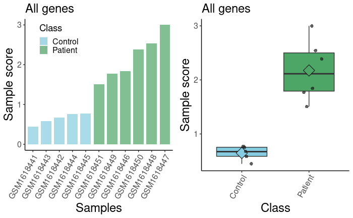

```r
# saving a plot as a PNG image
# png(filename = paste0("MDP_", gse, ".png"), width = 800, height = 600)


# Perform MDP analysis using median as the measure, considering the top 25% most perturbed genes
mdp_results <- mdp(data = expr2, pdata = phenoData_GEO_1, control_lab = "Control", measure = "median", fraction_genes = 0.25)
```

```r
# turn off the current graphics device:
# dev.off()
```

**Visualizing Sample Distributions Using ggplot**

Following the MDP analysis, visualizing the distribution of samples across different classes (e.g., Patient vs Control) is a crucial step. This visualization helps in understanding the composition of the dataset and ensures that there is a balanced representation of each class for valid comparative analysis.

The ggplot2 package in R is used for creating a bar plot that displays the frequency of each class. This plot not only shows the number of samples per class but also visually represents the balance or imbalance in sample sizes, which is vital for interpreting the results of transcriptomic analyses.

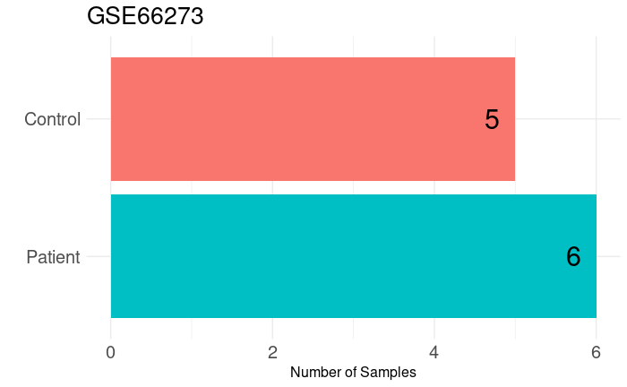

```r
# Create a frequency table for the 'Class' column
class_freq <- as.data.frame(table(phenoData_GEO_1$Class))

# Sort the frequency table
class_freq <- class_freq[order(class_freq$Freq), ]


# saving a plot as a PNG image
# png(filename = paste0("n_samples_", gse, ".png"), width = 800, height = 600)

ggplot(data = class_freq, aes(x = reorder(Var1, -Freq), y = Freq, fill = Var1)) +
  geom_bar(stat = "identity") +
  geom_text(aes(label = Freq), vjust = 0.5, hjust = 2, color = "black", size = 8) +
  ggtitle(paste(gse)) +
  theme_minimal() +
  coord_flip() +
  labs(x = "", y = "Number of Samples") +
  theme(legend.position = "none",
        plot.title = element_text(size = 20),      # Adjust plot title size
        axis.title = element_text(size = 12),      # Adjust axis titles size
        axis.text = element_text(size = 15))       # Adjust axis text size
```

```r
# turn off the current graphics device:
# dev.off()
```

## Differential expression analysis

**Create a Design Matrix**

The design matrix models the experimental setup. In your case, it differentiates between the patient and control groups.

```r
design <- model.matrix(~ Class, data=phenoData_GEO_1)
```

**Fit the Linear Model and Compute Statistics**

Use lmFit and eBayes functions from limma to fit the model and compute statistics for differential expression.

```r
fit <- lmFit(expr2, design)
fit <- eBayes(fit)
```

**Extract and Summarize the Results**

Generate a list of differentially expressed genes. Adjust the p-value threshold as needed (e.g., 0.05).

```r
top_genes <- topTable(fit, coef=2, number=nrow(expr2), adjust.method = "BH", sort.by="P")
```

**Volcano Plot**

It is a type of scatter plot commonly used in genomics to display the results of differential expression analyses. The plot shows statistical significance (P-value) versus magnitude of change (fold change), making it easy to identify genes that are significantly upregulated or downregulated.

```r
# saving a plot as a PNG image
# png(filename = paste0("Volvano_basic_", gse, ".png"), width = 800, height = 600)

# Initial volcano plot
plot(top_genes$logFC, -log10(top_genes$adj.P.Val),
     main = "Volcano Plot",
     xlab = "Log Fold Change",
     ylab = "-Log10 Adjusted P-value",
     las = 1,
     pch = 20)

# Adding horizontal line for adjusted p-value cutoff of 0.05
abline(h = -log10(0.05), col = "blue")
```

```r
# Adding vertical lines for log fold change cutoffs
abline(v = c(-1, 1), col = "blue")

# Highlighting significant genes based on expression
points(top_genes$logFC[top_genes$adj.P.Val < 0.05 & top_genes$logFC < -1],
       -log10(top_genes$adj.P.Val[top_genes$adj.P.Val < 0.05 & top_genes$logFC < -1]),
       pch = 20, col = "blue") # Downregulated genes
```

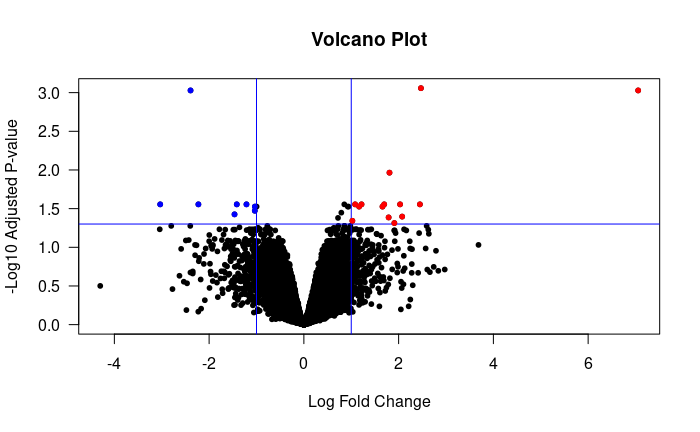

```r
points(top_genes$logFC[top_genes$adj.P.Val < 0.05 & top_genes$logFC > 1],
       -log10(top_genes$adj.P.Val[top_genes$adj.P.Val < 0.05 & top_genes$logFC > 1]),
       pch = 20, col = "red") # Upregulated genes
```

```r
# turn off the current graphics device:
# dev.off()
```

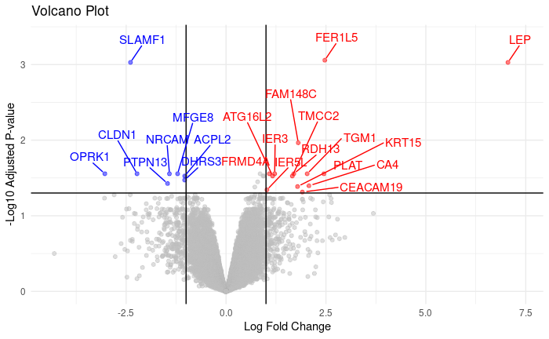

```r
# saving a plot as a PNG image
# png(filename = paste0("Volvano_", gse, ".png"), width = 800, height = 600)

# Creating a data frame for ggplot
volcano_data <- data.frame(
  Gene = rownames(top_genes),
  LogFC = top_genes$logFC,
  AdjPVal = -log10(top_genes$adj.P.Val),
  Significance = ifelse(top_genes$adj.P.Val < 0.05 & abs(top_genes$logFC) > 1, "Significant", "Not Significant")
)

# Add a new column for color coding
volcano_data$Color <- with(volcano_data, ifelse(Significance == "Significant" & LogFC > 0, "Red",
                                                ifelse(Significance == "Significant" & LogFC < 0, "Blue", "Grey")))

# Create the volcano plot
ggplot(volcano_data, aes(x = LogFC, y = AdjPVal)) +
  geom_point(aes(color = Color), alpha = 0.5) +
  scale_color_manual(values = c("Red" = "red", "Blue" = "blue", "Grey" = "grey")) +
  geom_vline(xintercept = c(-1, 1), col = "black") +
  geom_hline(yintercept = -log10(0.05), col = "black") +
  geom_text_repel(
    aes(label = ifelse(Significance == "Significant", Gene, ""), color = Color),
    size = 4,
    box.padding = unit(0.45, "lines"),
    point.padding = unit(0.4, "lines"),
    max.overlaps = 50,
    nudge_x = 0.3,
    nudge_y = 0.3
  ) +
  theme_minimal() +
  labs(title = "Volcano Plot", x = "Log Fold Change", y = "-Log10 Adjusted P-value") +
  theme(legend.position = "none")  # Hide the legend
```

```r
# turn off the current graphics device:
# dev.off()
```

**Heatmap**

This code filters a gene expression dataset for significant genes, creates a heatmap of these genes, and annotates it with information about the sample conditions.

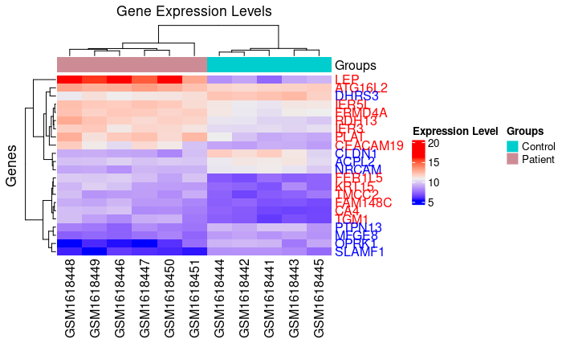

```r
# Setting thresholds for filtering genes
threshold_adj_pval <- 0.05  # Adjusted p-value threshold for significance
threshold_logFC <- 1        # Log fold change threshold for meaningful change

# Filtering significant genes based on thresholds
# Includes genes with adjusted p-value less than 0.05 and absolute log fold change greater than 1
significant_genes <- top_genes[top_genes$adj.P.Val < threshold_adj_pval & abs(top_genes$logFC) > threshold_logFC, ]

# Adding a column to indicate up (red) or down (blue) regulation for heatmap row labels
significant_genes$RegulationColor <- ifelse(significant_genes$logFC > 0, "red", "blue")

# Extracting expression data for significant genes to create the heatmap
heatmap_data <- expr2[rownames(expr2) %in% rownames(significant_genes), ]

# Converting data to a matrix format as required by the Heatmap function
heatmap_data_matrix <- as.matrix(heatmap_data)

# Defining sample conditions and their color scheme for the heatmap column annotation
conditions <- phenoData_GEO_1$Class  # Vector of sample conditions
condition_colors <- c("Patient" = "lightpink3", "Control" = "cyan3")  # Colors for conditions

# Creating column annotation for the heatmap
column_annotation <- HeatmapAnnotation(Groups = conditions, col = list(Groups = condition_colors))

# Aligning row label colors with the order of genes in the heatmap matrix
# This ensures that the row label colors correspond correctly to the genes in the heatmap
aligned_row_labels_colors <- significant_genes[match(rownames(heatmap_data_matrix), rownames(significant_genes)), "RegulationColor"]

# Creating the heatmap
Heatmap(heatmap_data_matrix,
        name = "Expression Level",  # Title for the heatmap legend
        show_row_names = TRUE,  # Display gene names
        row_names_gp = gpar(col = aligned_row_labels_colors),  # Coloring gene names based on regulation
        show_column_names = TRUE,  # Display sample names
        top_annotation = column_annotation,  # Adding annotation for sample conditions
        cluster_rows = TRUE,  # Clustering genes
        cluster_columns = TRUE,  # Clustering samples
        column_title = "Gene Expression Levels",  # Title for columns
        row_title = "Genes")  # Title for rows
```

**Gene Set Enrichment Analysis**

This is the preparation process for conducting Gene Set Enrichment Analysis (GSEA) using the FGSEA (Fast Gene Set Enrichment Analysis) approach.

```r
# Creating a data frame named 'geneList'
geneList <- data.frame(
  geneSymbol = rownames(top_genes),  # Replace with your gene symbols
  statistic = top_genes$logFC        # Replace with your statistics
)

# Sort the list based on the statistic
geneList <- geneList[order(geneList$statistic, decreasing = TRUE),]

# Create a named vector for FGSEA
rankedGenes <- setNames(geneList$statistic, geneList$geneSymbol)
```

**Gene Sets**

Hallmark and Reactome

The Hallmark gene sets are a collection curated as part of the Molecular Signatures Database (MSigDB) developed by the Broad Institute. These gene sets are designed to represent well-defined biological states or processes and have been refined to reduce redundancy and overlap.

Reactome is a free, open-source, curated, and peer-reviewed pathway database. Its goal is to provide intuitive bioinformatics tools for the visualization, interpretation, and analysis of pathway knowledge.

In the context of genomic analysis, such as GSEA, using these gene set collections can provide insights into which biological processes or pathways are significantly represented in the gene expression data. For example, if a set of genes upregulated under certain conditions significantly overlaps with a Reactome pathway, it suggests that this pathway might be active under those conditions. Similarly, the Hallmark gene sets can indicate broader biological themes or processes at play in the data.

```r
# Loading gene sets
hallmarks <- fgsea::gmtPathways("/home/vivischuch/class3/MSM_Rclass/hallmark.genesets.v6.1.symbols.gmt") #50 gene sets
reactome <- fgsea::gmtPathways("/home/vivischuch/class3/MSM_Rclass/reactome.genesets.v6.1.symbols.gmt") #674
# The `fgsea::gmtPathways` function is used to load gene sets stored in a GMT file.
```

**GSEA**

Using Hallmark gene sets.

```r
# Performing Fast Gene Set Enrichment Analysis (FGSEA) using Hallmark gene sets
fgseaResults_H <- fgsea(pathways = hallmarks,
                      stats = rankedGenes,
                      minSize = 15,     # Minimum size of a pathway to test
                      maxSize = 500)    # Max size of a pathway to test

# Filtering and sorting the FGSEA results for significant pathways
gsea_sig_H <- dplyr::filter(fgseaResults_H, padj <= 0.05) %>%
  arrange(NES)

# Printing the top entries of the filtered and sorted FGSEA results
print(head(gsea_sig_H))
```

| pathway | pval | padj | log2err | ES | NES | size | leadingEdge |
| --- | --- | --- | --- | --- | --- | --- | --- |
| HALLMARK_PEROXISOME | 0.000166 | 0.00207 | 0.519 | -0.473 | -1.87 | 102 |  |
| HALLMARK_PROTEIN_SECRETION | 0.000876 | 0.00876 | 0.477 | -0.444 | -1.74 | 95 |  |
| HALLMARK_UV_RESPONSE_DN | 0.001867 | 0.01037 | 0.455 | -0.387 | -1.62 | 139 |  |
| HALLMARK_REACTIVE_OXIGEN_SPECIES_PATHWAY | 0.011949 | 0.03701 | 0.381 | -0.462 | -1.57 | 47 |  |
| HALLMARK_COAGULATION | 0.005015 | 0.02280 | 0.407 | -0.372 | -1.55 | 138 |  |
| HALLMARK_EPITHELIAL_MESENCHYMAL_TRANSITION | 0.001864 | 0.01037 | 0.455 | -0.353 | -1.53 | 200 |  |

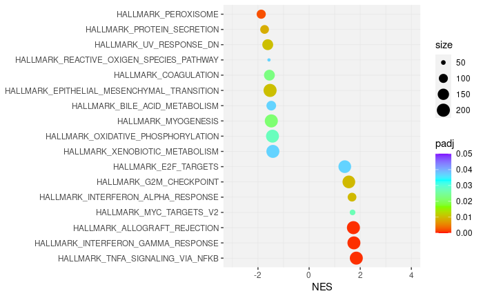

```r
# Creating a plot of the significant GSEA results
p <- ggplot(gsea_sig_H, aes(NES, pathway))
p + geom_point(aes(colour=padj, size=size)) +
    scale_color_gradientn(colours=rainbow(4), limits=c(0, 0.05)) +
    # geom_vline(xintercept=0, size=0.5, colour="gray50") +
    theme(panel.background=element_rect(fill="gray95", colour="gray95"),
          panel.grid.major=element_line(size=0.25,linetype='solid', colour="gray90"),
          panel.grid.minor=element_line(size=0.25,linetype='solid', colour="gray90"),
          axis.title.y=element_blank()) +
    expand_limits(x=c(-3,4)) +
    # scale_x_continuous(breaks=c(-3,-2,-1,0,1,2,3, 4)) +
    scale_y_discrete(limits=rev(gsea_sig_H$pathway))
```

**Using Reactome gene sets.**

```r
# Performing Fast Gene Set Enrichment Analysis (FGSEA) using Reactome gene sets
fgseaResults_R <- fgsea(pathways = reactome,
                      stats = rankedGenes,
                      minSize = 15,     # Minimum size of a pathway to test
                      maxSize = 500)    # Number of permutations


# Filtering and sorting the FGSEA results for significant pathways
gsea_sig_R <- dplyr::filter(fgseaResults_R, padj <= 0.05) %>%
  arrange(NES)

# Printing the top entries of the filtered and sorted FGSEA results
print(head(gsea_sig_R))
```

| pathway | pval | padj | log2err | ES | NES | size | leadingEdge |
| --- | --- | --- | --- | --- | --- | --- | --- |
| REACTOME_RNA_POL_I_PROMOTER_OPENING | 0.0000000536 | 0.0000269 | 0.720 | -0.651 | -2.29 | 56 |  |
| REACTOME_PACKAGING_OF_TELOMERE_ENDS | 0.0000004716 | 0.0001184 | 0.675 | -0.663 | -2.24 | 46 |  |
| REACTOME_GLUTATHIONE_CONJUGATION | 0.0000100805 | 0.0004303 | 0.593 | -0.736 | -2.12 | 23 |  |
| REACTOME_RNA_POL_I_TRANSCRIPTION | 0.0000033181 | 0.0002112 | 0.627 | -0.560 | -2.09 | 79 |  |
| REACTOME_PHASE_II_CONJUGATION | 0.0000111420 | 0.0004303 | 0.593 | -0.564 | -2.02 | 62 |  |
| REACTOME_GLUCAGON_SIGNALING_IN_METABOLIC_REGULATION | 0.0000535100 | 0.0016789 | 0.557 | -0.642 | -2.02 | 33 |  |

[figure not shown]

```r
# Creating a plot of the significant GSEA results
p <- ggplot(gsea_sig_R, aes(NES, pathway))
p + geom_point(aes(colour=padj, size=size)) +
    scale_color_gradientn(colours=rainbow(4), limits=c(0, 0.05)) +
    # geom_vline(xintercept=0, size=0.5, colour="gray50") +
    theme(panel.background=element_rect(fill="gray95", colour="gray95"),
          panel.grid.major=element_line(size=0.25,linetype='solid', colour="gray90"),
          panel.grid.minor=element_line(size=0.25,linetype='solid', colour="gray90"),
          axis.title.y=element_blank()) +
    expand_limits(x=c(-3,4)) +
    # scale_x_continuous(breaks=c(-3,-2,-1,0,1,2,3, 4)) +
    scale_y_discrete(limits=rev(gsea_sig_R$pathway))
```